# Lab 4: Mediation

Introduction to SEM in R with lavaan

Kyle M. Lang

Updated: 2026-02-27

In this lab, you will practice mediation analysis using **lavaan** and latent variables.

# 1 Data

We will first analyze the classic Holzinger & Swineford (1939) educational testing data. A full version of this dataset is distributed as the `HS` dataset in the **MBESS** package. We don’t need any functionality from **MBESS**, however, so I have provided a standalone (and mildly processed) version of the data as [*holzinger_swineford.rds*](https://github.com/kylelang/lavaan-e-learning/raw/main/data/holzinger_swineford.rds).

These data contain a number of educational test scores from 7th and 8th grade students in two schools. This dataset comprises 301 observations of the following 29 variables.

- `id`: Numeric ID
- `age`: Student age in years
- `sex`: Biological sex of the student
- `grade`: Grade of the student
- `school`: School at which the student was tested
- `spatial1:spatial4`: Scores on four spatial reasoning tests
- `verbal1:verbal5`: Scores on five tests of verbal ability
- `speed1:speed4`: Scores on four tests of cognitive processing speed
- `memory1:memory6`: Scores on six memory tests
- `math1:math5`: Scores on five tests of mathematical ability

In the following, we will use the test scores to define latent factors of the underlying ability levels.

You can access the original version of the data via the [**MBESS**](https://cran.r-project.org/web/packages/MBESS/index.html) package, and you can access the code used to process the data [here](https://github.com/kylelang/lavaan-e-learning/blob/main/code/lab_prep/process_hs_data.R).

## 1.1

**Read in the *holzinger_swineford.rds* dataset.**

```r
dataDir <- "data"
hs <- readRDS(here::here(dataDir, "holzinger_swineford.rds"))
```

NOTE: In the following, I will refer to these data as the *HS data*.

## 1.2

**Summarize the HS data to get a sense of their characteristics.**

```r
head(hs)
```

|  | id | age | sex | grade | school | spatial1 | spatial2 | spatial3 | spatial4 | verbal1 | verbal2 | verbal3 | verbal4 | verbal5 | speed1 | speed2 | speed3 | speed4 | memory1 | memory2 | memory3 | memory4 | memory5 | memory6 | math1 | math2 | math3 | math4 | math5 |
| --- | --- | --- | --- | --- | --- | --- | --- | --- | --- | --- | --- | --- | --- | --- | --- | --- | --- | --- | --- | --- | --- | --- | --- | --- | --- | --- | --- | --- | --- |
| 1 | 1 | 13.0833 | Male | 7 | Pasteur | -1.37261627 | 1.4114904 | -0.7876318 | -1.6582223135 | -0.04776472 | -0.6250018 | 1.0922114 | -0.7270348 | -0.8213354 | -0.7293009 | 0.3086874 | 0.2201464 | 0.9780371 | -0.4477785 | -0.5187958 | -0.8548237 | -0.4541536 | -0.09075064 | 0.481592188 | -1.2356752 | -0.05461514 | 0.8438179 | -1.4372357 | -0.0561283 |
| 2 | 2 | 13.5833 | Female | 7 | Pasteur | 0.34054543 | -0.7117410 | -0.7876318 | -0.1108908633 | -0.53238884 | -1.1976823 | -1.0387915 | -0.7270348 | -0.8213354 | -0.3701523 | 0.9468393 | 0.7139174 | 2.5194857 | 0.7688163 | -0.6481723 | -0.3307872 | 0.7663842 | 0.57549187 | -0.990075309 | -1.5460117 | -0.27380392 | -0.5696493 | -1.8748765 | -2.5903210 |
| 3 | 3 | 13.0833 | Female | 7 | Pasteur | -0.37327194 | -0.7117410 | -0.7876318 | -0.3319382133 | -1.66317844 | -1.7703627 | -2.0074293 | -2.4890112 | -1.6036833 | -0.8490170 | -1.2866923 | -1.6068063 | -0.9487737 | -0.4477785 | -0.6481723 | -0.9858328 | -1.4712684 | -0.97907400 | -1.971186974 | -1.5460117 | -1.15055905 | -0.8958341 | -1.2184153 | -0.9008592 |
| 4 | 4 | 13.1667 | Male | 7 | Pasteur | 0.34054543 | 1.4114904 | 0.6256450 | 0.6627748618 | 0.11377665 | -0.3386615 | 0.1235737 | -0.9032324 | 0.2217952 | -1.0884494 | -0.2656493 | -0.2242475 | -0.5083598 | 0.5081174 | -1.2950552 | -1.5098693 | -0.6575766 | -1.42323567 | -0.990075309 | -1.4942889 | -0.93137027 | -0.4609211 | -1.3278255 | -1.1120419 |
| 5 | 5 | 12.1667 | Female | 7 | Pasteur | -0.08774499 | -1.1363873 | -0.7876318 | -1.2161276135 | -0.29007678 | -0.3386615 | -0.2638814 | -0.1984419 | 0.3521865 | -0.4499631 | -0.3932797 | 0.7632945 | 0.5376232 | 1.0295152 | 1.1630997 | 0.1932493 | 1.3766531 | 1.01965355 | -0.008963645 | 0.1091161 | 0.16457364 | -0.7871058 | -1.5466459 | -0.9008592 |
| 6 | 6 | 14.0833 | Female | 7 | Pasteur | 0.34054543 | -0.9240642 | -1.1409510 | -0.0003671883 | -0.77470090 | -1.7703627 | -1.0387915 | -0.1984419 | -1.2125093 | 0.1486178 | 1.4573609 | 1.1089342 | 2.1065977 | -0.9691762 | -0.7775489 | 0.1932493 | -0.4541536 | -0.75699316 | -0.008963645 | -0.9253388 | -2.68488051 | -1.1132906 | -0.8901847 | -0.4784937 |

```r
summary(hs)
```

```
       id             age            sex      grade           school
 Min.   :  1.0   Min.   :11.33   Female:155   7:157   Grant-White:145
 1st Qu.: 82.0   1st Qu.:12.67   Male  :146   8:144   Pasteur    :156
 Median :163.0   Median :13.25
 Mean   :176.6   Mean   :13.44
 3rd Qu.:272.0   3rd Qu.:14.00
 Max.   :351.0   Max.   :16.58
    spatial1           spatial2           spatial3           spatial4
 Min.   :-3.65683   Min.   :-3.25962   Min.   :-2.90755   Min.   :-1.7687
 1st Qu.:-0.65880   1st Qu.:-0.71174   1st Qu.:-0.78763   1st Qu.:-0.7740
 Median : 0.05502   Median :-0.07477   Median :-0.08099   Median :-0.1109
 Mean   : 0.00000   Mean   : 0.00000   Mean   : 0.00000   Mean   : 0.0000
 3rd Qu.: 0.62607   3rd Qu.: 0.56220   3rd Qu.: 0.62565   3rd Qu.: 0.7733
 Max.   : 3.05305   Max.   : 2.68543   Max.   : 3.80552   Max.   : 1.9891
    verbal1            verbal2            verbal3           verbal4
 Min.   :-2.63243   Min.   :-2.62938   Min.   :-2.5886   Min.   :-2.84141
 1st Qu.:-0.77470   1st Qu.:-0.62500   1st Qu.:-0.6513   1st Qu.:-0.55084
 Median : 0.03301   Median :-0.05232   Median : 0.1236   Median :-0.02224
 Mean   : 0.00000   Mean   : 0.00000   Mean   : 0.0000   Mean   : 0.00000
 3rd Qu.: 0.67917   3rd Qu.: 0.52036   3rd Qu.: 0.7048   3rd Qu.: 0.68255
 Max.   : 3.50615   Max.   : 2.81108   Max.   : 2.0608   Max.   : 2.97312
    verbal5            speed1             speed2            speed3
 Min.   :-1.8645   Min.   :-2.64476   Min.   :-3.2011   Min.   :-2.44622
 1st Qu.:-0.6909   1st Qu.:-0.64949   1st Qu.:-0.5847   1st Qu.:-0.66864
 Median :-0.1694   Median :-0.09081   Median :-0.0742   Median :-0.02674
 Mean   : 0.0000   Mean   : 0.00000   Mean   : 0.0000   Mean   : 0.00000
 3rd Qu.: 0.4826   3rd Qu.: 0.66739   3rd Qu.: 0.6278   3rd Qu.: 0.56579
 Max.   : 3.6120   Max.   : 2.98190   Max.   : 3.1166   Max.   : 4.41720
     speed4            memory1            memory2             memory3
 Min.   :-2.57280   Min.   :-4.70586   Min.   :-2.847574   Min.   :-5.83317
 1st Qu.:-0.61846   1st Qu.:-0.62158   1st Qu.:-0.777549   1st Qu.:-0.59281
 Median : 0.04216   Median : 0.07362   Median :-0.001289   Median : 0.06224
 Mean   : 0.00000   Mean   : 0.00000   Mean   : 0.000000   Mean   : 0.00000
 3rd Qu.: 0.70278   3rd Qu.: 0.76882   3rd Qu.: 0.774970   3rd Qu.: 0.58628
 Max.   : 3.84073   Max.   : 1.98541   Max.   : 2.844995   Max.   : 2.15839
    memory4            memory5            memory6              math1
 Min.   :-1.67469   Min.   :-2.08948   Min.   :-2.707021   Min.   :-2.32185
 1st Qu.:-0.65758   1st Qu.:-0.75699   1st Qu.:-0.744797   1st Qu.:-0.77017
 Median :-0.04731   Median :-0.09075   Median :-0.008964   Median :-0.04605
 Mean   : 0.00000   Mean   : 0.00000   Mean   : 0.000000   Mean   : 0.00000
 3rd Qu.: 0.56296   3rd Qu.: 0.57549   3rd Qu.: 0.726870   3rd Qu.: 0.62634
 Max.   : 3.61431   Max.   : 2.35214   Max.   : 1.462704   Max.   : 3.10904
     math2              math3              math4              math5
 Min.   :-2.90407   Min.   :-2.09184   Min.   :-1.87488   Min.   :-2.8015
 1st Qu.:-0.49299   1st Qu.:-0.78711   1st Qu.:-0.78077   1st Qu.:-0.6897
 Median :-0.05462   Median :-0.02601   Median : 0.09451   Median : 0.1551
 Mean   : 0.00000   Mean   : 0.00000   Mean   : 0.00000   Mean   : 0.0000
 3rd Qu.: 0.60295   3rd Qu.: 0.62636   3rd Qu.: 0.64156   3rd Qu.: 0.7886
 Max.   : 2.13727   Max.   : 2.58347   Max.   : 2.39212   Max.   : 2.2669
```

```r
str(hs)
```

```
'data.frame':   301 obs. of  29 variables:
 $ id      : int  1 2 3 4 5 6 7 8 9 11 ...
 $ age     : num  13.1 13.6 13.1 13.2 12.2 ...
 $ sex     : Factor w/ 2 levels "Female","Male": 2 1 1 2 1 1 2 1 1 1 ...
 $ grade   : Factor w/ 2 levels "7","8": 1 1 1 1 1 1 1 1 1 1 ...
 $ school  : Factor w/ 2 levels "Grant-White",..: 2 2 2 2 2 2 2 2 2 2 ...
 $ spatial1: num  -1.3726 0.3405 -0.3733 0.3405 -0.0877 ...
 $ spatial2: num  1.411 -0.712 -0.712 1.411 -1.136 ...
 $ spatial3: num  -0.788 -0.788 -0.788 0.626 -0.788 ...
 $ spatial4: num  -1.658 -0.111 -0.332 0.663 -1.216 ...
 $ verbal1 : num  -0.0478 -0.5324 -1.6632 0.1138 -0.2901 ...
 $ verbal2 : num  -0.625 -1.198 -1.77 -0.339 -0.339 ...
 $ verbal3 : num  1.092 -1.039 -2.007 0.124 -0.264 ...
 $ verbal4 : num  -0.727 -0.727 -2.489 -0.903 -0.198 ...
 $ verbal5 : num  -0.821 -0.821 -1.604 0.222 0.352 ...
 $ speed1  : num  -0.729 -0.37 -0.849 -1.088 -0.45 ...
 $ speed2  : num  0.309 0.947 -1.287 -0.266 -0.393 ...
 $ speed3  : num  0.22 0.714 -1.607 -0.224 0.763 ...
 $ speed4  : num  0.978 2.519 -0.949 -0.508 0.538 ...
 $ memory1 : num  -0.448 0.769 -0.448 0.508 1.03 ...
 $ memory2 : num  -0.519 -0.648 -0.648 -1.295 1.163 ...
 $ memory3 : num  -0.855 -0.331 -0.986 -1.51 0.193 ...
 $ memory4 : num  -0.454 0.766 -1.471 -0.658 1.377 ...
 $ memory5 : num  -0.0908 0.5755 -0.9791 -1.4232 1.0197 ...
 $ memory6 : num  0.48159 -0.99008 -1.97119 -0.99008 -0.00896 ...
 $ math1   : num  -1.236 -1.546 -1.546 -1.494 0.109 ...
 $ math2   : num  -0.0546 -0.2738 -1.1506 -0.9314 0.1646 ...
 $ math3   : num  0.844 -0.57 -0.896 -0.461 -0.787 ...
 $ math4   : num  -1.44 -1.87 -1.22 -1.33 -1.55 ...
 $ math5   : num  -0.0561 -2.5903 -0.9009 -1.112 -0.9009 ...
```

# 2 Simple Mediation 1

First, we will consider a simple mediation model wherein the effect of *student age* on *spatial reasoning ability* is mediated by *mathematical ability*.

## 2.1

**Draw a path diagram for the model described above.**

- Label the relevant structural paths.

[figure not shown]

## 2.2

**Write out the structural equations necessary to evaluate the mediation hypothesis described above.**

$$\begin{align}
\eta_{spatial} &= b \eta_{math} + c' X_{age} + \varepsilon_2\\
\eta_{math} &= a X_{age} + \varepsilon_1
\end{align}$$

## 2.3

**Define the model syntax for the CFA.**

- Indicated the *spatial reasoning ability* factor from the four observed spatial reasoning test scores.
  - `spatial1:spatial4`
- Indicated the *mathematical ability* factor from the five observed math test scores.
  - `math1:math5`

```r
cfaMod1 <- '
spatial =~ spatial1 + spatial2 + spatial3 + spatial4
math    =~ math1    + math2    + math3    + math4    + math5
'
```

## 2.4

**Estimate the CFA model on the HS data.**

- Correlate the latent factors.
- Set the scale by standardizing the latent factors.
- Do not include any mean structure.

```r
library(lavaan)
cfaFit1 <- cfa(cfaMod1, data = hs, std.lv = TRUE)
```

## 2.5

**Summarize the fitted CFA and check the model fit.**

- Do the parameter estimates look sensible?
- Does the model fit the data well enough?

```r
summary(cfaFit1)
```

```
lavaan 0.6-21 ended normally after 15 iterations

  Estimator                                         ML
  Optimization method                           NLMINB
  Number of model parameters                        19

  Number of observations                           301

Model Test User Model:

  Test statistic                                36.224
  Degrees of freedom                                26
  P-value (Chi-square)                           0.088

Parameter Estimates:

  Standard errors                             Standard
  Information                                 Expected
  Information saturated (h1) model          Structured

Latent Variables:
                   Estimate  Std.Err  z-value  P(>|z|)
  spatial =~
    spatial1          0.717    0.059   12.199    0.000
    spatial2          0.476    0.062    7.673    0.000
    spatial3          0.476    0.062    7.666    0.000
    spatial4          0.625    0.060   10.465    0.000
  math =~
    math1             0.601    0.057   10.543    0.000
    math2             0.627    0.056   11.123    0.000
    math3             0.661    0.056   11.872    0.000
    math4             0.787    0.053   14.909    0.000
    math5             0.576    0.057   10.016    0.000

Covariances:
                   Estimate  Std.Err  z-value  P(>|z|)
  spatial ~~
    math              0.784    0.046   17.081    0.000

Variances:
                   Estimate  Std.Err  z-value  P(>|z|)
   .spatial1          0.483    0.060    8.060    0.000
   .spatial2          0.770    0.069   11.144    0.000
   .spatial3          0.770    0.069   11.147    0.000
   .spatial4          0.605    0.062    9.744    0.000
   .math1             0.636    0.059   10.816    0.000
   .math2             0.603    0.057   10.592    0.000
   .math3             0.560    0.055   10.255    0.000
   .math4             0.377    0.047    8.021    0.000
   .math5             0.665    0.060   10.997    0.000
    spatial           1.000
    math              1.000
```

```r
fitMeasures(cfaFit1)
```

```
                 npar                  fmin                 chisq
               19.000                 0.060                36.224
                   df                pvalue        baseline.chisq
               26.000                 0.088               709.294
          baseline.df       baseline.pvalue                   cfi
               36.000                 0.000                 0.985
                  tli                  nnfi                   rfi
                0.979                 0.979                 0.929
                  nfi                  pnfi                   ifi
                0.949                 0.685                 0.985
                  rni                  logl     unrestricted.logl
                0.985             -3502.862             -3484.750
                  aic                   bic                ntotal
             7043.725              7114.160               301.000
                 bic2                 rmsea        rmsea.ci.lower
             7053.902                 0.036                 0.000
       rmsea.ci.upper        rmsea.ci.level          rmsea.pvalue
                0.062                 0.900                 0.787
       rmsea.close.h0 rmsea.notclose.pvalue     rmsea.notclose.h0
                0.050                 0.001                 0.080
                  rmr            rmr_nomean                  srmr
                0.037                 0.037                 0.037
         srmr_bentler   srmr_bentler_nomean                  crmr
                0.037                 0.037                 0.041
          crmr_nomean            srmr_mplus     srmr_mplus_nomean
                0.041                 0.037                 0.037
                cn_05                 cn_01                   gfi
              324.111               380.254                 0.975
                 agfi                  pgfi                   mfi
                0.957                 0.563                 0.983
                 ecvi
                0.247
```

The model looks good. All measurement model parameters seem reasonable, and the model fits the data well.

## 2.6

**Define the model syntax for the structural model.**

- Specify all paths needed to test the mediation hypothesis described above.
- Include a defined parameter to quantify the indirect effect.

```r
## Define only the new structural parts:
semMod1 <- '
spatial ~ b * math + c * age
math    ~ a * age

ab := a * b
'

## Add on the measurement part:
semMod1 <- paste(cfaMod1, semMod1, sep = '\n')
```

## 2.7

**Estimate the structural model.**

- Do not use bootstrapping.
- Test the significance of the indirect effect using Sobel’s Z.

```r
semFit1 <- sem(semMod1, data = hs, std.lv = TRUE)
summary(semFit1)
```

```
lavaan 0.6-21 ended normally after 19 iterations

  Estimator                                         ML
  Optimization method                           NLMINB
  Number of model parameters                        21

  Number of observations                           301

Model Test User Model:

  Test statistic                                42.238
  Degrees of freedom                                33
  P-value (Chi-square)                           0.130

Parameter Estimates:

  Standard errors                             Standard
  Information                                 Expected
  Information saturated (h1) model          Structured

Latent Variables:
                   Estimate  Std.Err  z-value  P(>|z|)
  spatial =~
    spatial1          0.423    0.055    7.631    0.000
    spatial2          0.286    0.046    6.212    0.000
    spatial3          0.288    0.046    6.254    0.000
    spatial4          0.378    0.051    7.374    0.000
  math =~
    math1             0.585    0.056   10.457    0.000
    math2             0.611    0.055   11.034    0.000
    math3             0.647    0.055   11.861    0.000
    math4             0.779    0.052   15.074    0.000
    math5             0.564    0.056   10.022    0.000

Regressions:
                   Estimate  Std.Err  z-value  P(>|z|)
  spatial ~
    math       (b)    1.339    0.210    6.382    0.000
    age        (c)    0.284    0.102    2.775    0.006
  math ~
    age        (a)   -0.195    0.064   -3.043    0.002

Variances:
                   Estimate  Std.Err  z-value  P(>|z|)
   .spatial1          0.497    0.060    8.347    0.000
   .spatial2          0.769    0.069   11.157    0.000
   .spatial3          0.764    0.069   11.128    0.000
   .spatial4          0.598    0.062    9.705    0.000
   .math1             0.642    0.059   10.900    0.000
   .math2             0.609    0.057   10.689    0.000
   .math3             0.561    0.054   10.334    0.000
   .math4             0.366    0.046    7.966    0.000
   .math5             0.666    0.060   11.042    0.000
   .spatial           1.000
   .math              1.000

Defined Parameters:
                   Estimate  Std.Err  z-value  P(>|z|)
    ab               -0.261    0.094   -2.773    0.006
```

## 2.8

**Interpret the results.**

1. Is the indirect effect significant according to the above test?
2. Briefly interpret the indirect effect.
3. What caveats might you place on this finding?

**Answers:**

1. Yes, the indirect effect is statistically significant $(ab = -0.261,$ $\mathit{SE} = 0.094,$ $z = -2.773,$ $p = 0.006).$
2. There is a significant, negative effect of age on spatial reasoning ability transmitted through mathematical ability.
3. The normality assumption underlying the Sobel test may not be appropriate. We should test the significance of our indirect effect using bootstrapping.

## 2.9

**Test the indirect effect using bootstrapping.**

- Rerun the structural model from 2.7 using $B = 2000$ bootstrap resamples.
- Test the significance of the indirect effect via the 95% bias-corrected (BC) CI.
- Is the indirect effect also significant according to the bootstrapped CI?

```r
library(dplyr)

# Specify the number of bootstrap samples:
nSams <- 2000

## Estimate the model with bootstrapped standard errors:
semFit1.2 <- sem(semMod1,
                 data      = hs,
                 std.lv    = TRUE,
                 se        = "boot",
                 bootstrap = nSams)

## Get the CI for the indirect effect:
## NOTE: boot.ci.type = "bca.simple" only corrects for bias, not skewness. So,
##       these are bias-corrected CIs, not bias-corrected and accelerated.
parameterEstimates(semFit1.2, boot.ci.type = "bca.simple") |>
  select(-(1:3)) |>
  tail(1)
```

|  | label | est | se | z | pvalue | ci.lower | ci.upper |
| --- | --- | --- | --- | --- | --- | --- | --- |
| 25 | ab | -0.2610622 | 0.1002507 | -2.604094 | 0.009211762 | -0.4906736 | -0.09724481 |

Yes, the 95% bootstrapped CI, (-0.491; -0.097), does not include zero, so we can infer a statistically significant indirect effect at the $\alpha = 0.05$ level.

# 3 Simple Mediation 2

Next, we will consider another simple mediation model wherein the effect of *student age* on *spatial reasoning ability* is mediated by *verbal ability*.

## 3.1

**Define the model syntax for the CFA.**

- Indicated the *spatial reasoning ability* factor from the four observed spatial reasoning test scores.
  - `spatial1:spatial4`
- Indicated the *verbal ability* factor from the five observed verbal test scores.
  - `verbal1:verbal5`

```r
cfaMod2 <- '
spatial =~ spatial1 + spatial2 + spatial3 + spatial4
verbal  =~ verbal1  + verbal2  + verbal3  + verbal4  + verbal5
'
```

## 3.2

**Estimate the CFA model on the HS data.**

- Correlate the latent factors.
- Set the scale by standardizing the latent factors.
- Do not include any mean structure.

```r
cfaFit2 <- cfa(cfaMod2, data = hs, std.lv = TRUE)
```

## 3.3

**Summarize the fitted CFA and check the model fit.**

- Do the parameter estimates look sensible?
- Does the model fit the data well enough?

```r
summary(cfaFit2)
```

```
lavaan 0.6-21 ended normally after 25 iterations

  Estimator                                         ML
  Optimization method                           NLMINB
  Number of model parameters                        19

  Number of observations                           301

Model Test User Model:

  Test statistic                                54.802
  Degrees of freedom                                26
  P-value (Chi-square)                           0.001

Parameter Estimates:

  Standard errors                             Standard
  Information                                 Expected
  Information saturated (h1) model          Structured

Latent Variables:
                   Estimate  Std.Err  z-value  P(>|z|)
  spatial =~
    spatial1          0.743    0.065   11.515    0.000
    spatial2          0.452    0.065    6.953    0.000
    spatial3          0.507    0.064    7.870    0.000
    spatial4          0.585    0.064    9.145    0.000
  verbal =~
    verbal1           0.835    0.048   17.476    0.000
    verbal2           0.819    0.048   16.958    0.000
    verbal3           0.867    0.047   18.546    0.000
    verbal4           0.738    0.051   14.556    0.000
    verbal5           0.846    0.047   17.840    0.000

Covariances:
                   Estimate  Std.Err  z-value  P(>|z|)
  spatial ~~
    verbal            0.457    0.061    7.537    0.000

Variances:
                   Estimate  Std.Err  z-value  P(>|z|)
   .spatial1          0.444    0.072    6.140    0.000
   .spatial2          0.793    0.072   11.004    0.000
   .spatial3          0.740    0.070   10.530    0.000
   .spatial4          0.654    0.069    9.546    0.000
   .verbal1           0.300    0.031    9.679    0.000
   .verbal2           0.326    0.033    9.989    0.000
   .verbal3           0.245    0.028    8.845    0.000
   .verbal4           0.453    0.041   10.951    0.000
   .verbal5           0.281    0.030    9.428    0.000
    spatial           1.000
    verbal            1.000
```

```r
fitMeasures(cfaFit2)
```

```
                 npar                  fmin                 chisq
               19.000                 0.091                54.802
                   df                pvalue        baseline.chisq
               26.000                 0.001              1247.314
          baseline.df       baseline.pvalue                   cfi
               36.000                 0.000                 0.976
                  tli                  nnfi                   rfi
                0.967                 0.967                 0.939
                  nfi                  pnfi                   ifi
                0.956                 0.690                 0.976
                  rni                  logl     unrestricted.logl
                0.976             -3243.141             -3215.740
                  aic                   bic                ntotal
             6524.281              6594.716               301.000
                 bic2                 rmsea        rmsea.ci.lower
             6534.459                 0.061                 0.038
       rmsea.ci.upper        rmsea.ci.level          rmsea.pvalue
                0.083                 0.900                 0.201
       rmsea.close.h0 rmsea.notclose.pvalue     rmsea.notclose.h0
                0.050                 0.080                 0.080
                  rmr            rmr_nomean                  srmr
                0.044                 0.044                 0.044
         srmr_bentler   srmr_bentler_nomean                  crmr
                0.044                 0.044                 0.049
          crmr_nomean            srmr_mplus     srmr_mplus_nomean
                0.049                 0.044                 0.044
                cn_05                 cn_01                   gfi
              214.578               251.688                 0.963
                 agfi                  pgfi                   mfi
                0.936                 0.556                 0.953
                 ecvi
                0.308
```

This model also looks good. All measurement model parameters seem reasonable, and the model fits the data well.

## 3.4

**Define the model syntax for the structural model.**

- Specify all paths needed to test the mediation hypothesis described above.
- Include a defined parameter to quantify the indirect effect.

```r
## Define only the new structural parts:
semMod2 <- '
spatial ~ b * verbal + c * age
verbal  ~ a * age

ab := a * b
'

## Add on the measurement part:
semMod2 <- paste(cfaMod2, semMod2, sep = '\n')
```

## 3.5

**Estimate the structural model.**

- Use B = 2000 bootstrap resamples to quantify the sampling variability.

```r
semFit2 <- sem(semMod2, data = hs, std.lv = TRUE, se = "boot", bootstrap = nSams)
summary(semFit2)
```

```
lavaan 0.6-21 ended normally after 23 iterations

  Estimator                                         ML
  Optimization method                           NLMINB
  Number of model parameters                        21

  Number of observations                           301

Model Test User Model:

  Test statistic                                64.340
  Degrees of freedom                                33
  P-value (Chi-square)                           0.001

Parameter Estimates:

  Standard errors                            Bootstrap
  Number of requested bootstrap draws             2000
  Number of successful bootstrap draws            2000

Latent Variables:
                   Estimate  Std.Err  z-value  P(>|z|)
  spatial =~
    spatial1          0.647    0.066    9.846    0.000
    spatial2          0.400    0.065    6.120    0.000
    spatial3          0.454    0.067    6.823    0.000
    spatial4          0.519    0.062    8.305    0.000
  verbal =~
    verbal1           0.808    0.050   16.101    0.000
    verbal2           0.795    0.049   16.366    0.000
    verbal3           0.843    0.038   22.017    0.000
    verbal4           0.718    0.050   14.364    0.000
    verbal5           0.819    0.054   15.173    0.000

Regressions:
                   Estimate  Std.Err  z-value  P(>|z|)
  spatial ~
    verbal     (b)    0.536    0.118    4.545    0.000
    age        (c)    0.142    0.083    1.717    0.086
  verbal ~
    age        (a)   -0.246    0.059   -4.199    0.000

Variances:
                   Estimate  Std.Err  z-value  P(>|z|)
   .spatial1          0.458    0.088    5.217    0.000
   .spatial2          0.791    0.077   10.216    0.000
   .spatial3          0.731    0.076    9.620    0.000
   .spatial4          0.650    0.067    9.767    0.000
   .verbal1           0.304    0.030   10.127    0.000
   .verbal2           0.325    0.033    9.784    0.000
   .verbal3           0.242    0.029    8.217    0.000
   .verbal4           0.449    0.043   10.531    0.000
   .verbal5           0.283    0.033    8.610    0.000
   .spatial           1.000
   .verbal            1.000

Defined Parameters:
                   Estimate  Std.Err  z-value  P(>|z|)
    ab               -0.132    0.042   -3.129    0.002
```

## 3.6

**Interpret the results.**

1. Is the indirect effect significant according to the 95% *percentile CI*?
2. Is the indirect effect significant according to the 95% *BC CI*?
3. Briefly interpret the indirect effect using the most appropriate version of the CI to support your conclusions.

```r
## Percentile CI:
parameterEstimates(semFit2, boot.ci.type = "perc") |>
  select(-(1:3)) |>
  tail(1)
```

|  | label | est | se | z | pvalue | ci.lower | ci.upper |
| --- | --- | --- | --- | --- | --- | --- | --- |
| 25 | ab | -0.1316191 | 0.04206678 | -3.128813 | 0.001755138 | -0.2270917 | -0.06203845 |

```r
## BC CI:
parameterEstimates(semFit2, boot.ci.type = "bca.simple") |>
  select(-(1:3)) |>
  tail(1)
```

|  | label | est | se | z | pvalue | ci.lower | ci.upper |
| --- | --- | --- | --- | --- | --- | --- | --- |
| 25 | ab | -0.1316191 | 0.04206678 | -3.128813 | 0.001755138 | -0.2292472 | -0.06364395 |

1. Yes, the indirect effect is statistically significant according to the percentile CI $(ab = -0.132,$ $95\%~\mathit{CI}_{perc} = [-0.227; -0.062]).$
2. Yes, the indirect effect is statistically significant according to the BC CI $(ab = -0.132,$ $95\%~\mathit{CI}_{BC} = [-0.229; -0.064]).$
3. The 95% BC CI for the indirect effect does not contain zero, so we can infer a significant, negative effect of age on spatial reasoning ability transmitted through verbal ability.

# 4 Parallel Multiple Mediation

Now, we will fit a multiple mediator model that combines the two simple mediation models evaluated above. This model will encode a process by which the effect of *student age* on *spatial reasoning ability* is indirectly transmitted by *mathematical ability* and *verbal ability* as parallel mediators.

## 4.1

**Define the model syntax for the CFA.**

- Indicated the *spatial reasoning ability* factor from the four observed spatial reasoning test scores.
  - `spatial1:spatial4`
- Indicated the *mathematical ability* factor from the five observed math test scores.
  - `math1:math5`
- Indicated the *verbal ability* factor from the five observed verbal test scores.
  - `verbal1:verbal5`

```r
cfaMod3 <- '
spatial =~ spatial1 + spatial2 + spatial3 + spatial4
math    =~ math1    + math2    + math3    + math4    + math5
verbal  =~ verbal1  + verbal2  + verbal3  + verbal4  + verbal5
'
```

## 4.2

**Estimate the CFA model on the HS data.**

- Correlate the latent factors.
- Set the scale by standardizing the latent factors.
- Do not include any mean structure.

```r
cfaFit3 <- cfa(cfaMod3, data = hs, std.lv = TRUE)
```

## 4.3

**Summarize the fitted CFA and check the model fit.**

- Do the parameter estimates look sensible?
- Does the model fit the data well enough?

```r
summary(cfaFit3)
```

```
lavaan 0.6-21 ended normally after 23 iterations

  Estimator                                         ML
  Optimization method                           NLMINB
  Number of model parameters                        31

  Number of observations                           301

Model Test User Model:

  Test statistic                               120.483
  Degrees of freedom                                74
  P-value (Chi-square)                           0.001

Parameter Estimates:

  Standard errors                             Standard
  Information                                 Expected
  Information saturated (h1) model          Structured

Latent Variables:
                   Estimate  Std.Err  z-value  P(>|z|)
  spatial =~
    spatial1          0.718    0.059   12.203    0.000
    spatial2          0.477    0.062    7.671    0.000
    spatial3          0.475    0.062    7.648    0.000
    spatial4          0.624    0.060   10.434    0.000
  math =~
    math1             0.598    0.056   10.673    0.000
    math2             0.610    0.056   10.946    0.000
    math3             0.689    0.054   12.766    0.000
    math4             0.767    0.052   14.754    0.000
    math5             0.595    0.056   10.612    0.000
  verbal =~
    verbal1           0.832    0.048   17.401    0.000
    verbal2           0.820    0.048   17.021    0.000
    verbal3           0.864    0.047   18.470    0.000
    verbal4           0.739    0.051   14.633    0.000
    verbal5           0.850    0.047   18.009    0.000

```

[output cut: 12 more lines]

```
   .spatial3          0.771    0.069   11.144    0.000
   .spatial4          0.607    0.062    9.743    0.000
   .math1             0.639    0.058   11.101    0.000
   .math2             0.624    0.057   11.022    0.000
   .math3             0.522    0.050   10.353    0.000
   .math4             0.408    0.044    9.184    0.000
   .math5             0.643    0.058   11.118    0.000
   .verbal1           0.305    0.031    9.860    0.000
   .verbal2           0.324    0.032   10.073    0.000
   .verbal3           0.251    0.028    9.099    0.000
   .verbal4           0.450    0.041   10.993    0.000
   .verbal5           0.274    0.029    9.461    0.000
    spatial           1.000
    math              1.000
    verbal            1.000
```

```r
fitMeasures(cfaFit3)
```

```
                 npar                  fmin                 chisq
               31.000                 0.200               120.483
                   df                pvalue        baseline.chisq
               74.000                 0.001              1919.034
          baseline.df       baseline.pvalue                   cfi
               91.000                 0.000                 0.975
                  tli                  nnfi                   rfi
                0.969                 0.969                 0.923
                  nfi                  pnfi                   ifi
                0.937                 0.762                 0.975
                  rni                  logl     unrestricted.logl
                0.975             -5073.120             -5012.878
                  aic                   bic                ntotal
            10208.239             10323.159               301.000
                 bic2                 rmsea        rmsea.ci.lower
            10224.845                 0.046                 0.030
       rmsea.ci.upper        rmsea.ci.level          rmsea.pvalue
                0.060                 0.900                 0.671
       rmsea.close.h0 rmsea.notclose.pvalue     rmsea.notclose.h0
                0.050                 0.000                 0.080
                  rmr            rmr_nomean                  srmr
                0.047                 0.047                 0.048
         srmr_bentler   srmr_bentler_nomean                  crmr
                0.048                 0.048                 0.051
          crmr_nomean            srmr_mplus     srmr_mplus_nomean
                0.051                 0.048                 0.048
                cn_05                 cn_01                   gfi
              238.541               263.825                 0.949
                 agfi                  pgfi                   mfi
                0.927                 0.668                 0.926
                 ecvi
                0.606
```

This model looks good, too. All measurement model parameters seem reasonable, and the model fits the data well.

## 4.4

**Define the model syntax for the structural model.**

- Specify all paths needed to test the multiple mediation hypothesis described above.
- Include defined parameters to quantify all specific indirect effects and the total indirect effect.

```r
## Define only the new structural parts:
semMod3 <- '
spatial ~ b1 * math + b2 * verbal + c * age
math    ~ a1 * age
verbal  ~ a2 * age

ab1 := a1 * b1
ab2 := a2 * b2
ie  := ab1 + ab2
'

## Add on the measurement part:
semMod3 <- paste(cfaMod3, semMod3, sep = '\n')
```

## 4.5

**Estimate the structural model.**

- Use B = 2000 bootstrap resamples to quantify the sampling variability.

```r
semFit3 <- sem(semMod3, data = hs, std.lv = TRUE, se = "boot", bootstrap = nSams)
summary(semFit3)
```

```
lavaan 0.6-21 ended normally after 28 iterations

  Estimator                                         ML
  Optimization method                           NLMINB
  Number of model parameters                        33

  Number of observations                           301

Model Test User Model:

  Test statistic                               262.838
  Degrees of freedom                                86
  P-value (Chi-square)                           0.000

Parameter Estimates:

  Standard errors                            Bootstrap
  Number of requested bootstrap draws             2000
  Number of successful bootstrap draws            2000

Latent Variables:
                   Estimate  Std.Err  z-value  P(>|z|)
  spatial =~
    spatial1          0.428    0.063    6.837    0.000
    spatial2          0.287    0.048    6.031    0.000
    spatial3          0.291    0.055    5.291    0.000
    spatial4          0.379    0.052    7.353    0.000
  math =~
    math1             0.584    0.055   10.563    0.000
    math2             0.611    0.055   11.011    0.000
    math3             0.647    0.052   12.326    0.000
    math4             0.779    0.048   16.108    0.000
    math5             0.565    0.057    9.892    0.000
  verbal =~
    verbal1           0.809    0.050   16.060    0.000
    verbal2           0.793    0.049   16.247    0.000
    verbal3           0.848    0.038   22.167    0.000
    verbal4           0.715    0.050   14.309    0.000
    verbal5           0.816    0.053   15.250    0.000

```

[output cut: 21 more lines]

```
   .math5             0.665    0.054   12.337    0.000
   .verbal1           0.301    0.031    9.836    0.000
   .verbal2           0.329    0.034    9.782    0.000
   .verbal3           0.233    0.029    7.977    0.000
   .verbal4           0.453    0.043   10.564    0.000
   .verbal5           0.290    0.034    8.528    0.000
   .spatial           1.000
   .math              1.000
   .verbal            1.000

Defined Parameters:
                   Estimate  Std.Err  z-value  P(>|z|)
    ab1              -0.254    0.107   -2.361    0.018
    ab2              -0.011    0.040   -0.283    0.777
    ie               -0.265    0.101   -2.621    0.009
```

## 4.6

**Interpret the results.**

1. Is the specific indirect effect through *mathematical ability* significant according to the 95% BC CI?
2. Is the specific indirect effect through *verbal ability* significant according to the 95% BC CI?
3. Is the total indirect effect significant according to the 95% BC CI?
4. Briefly interpret the indirect effects.
5. Do these results match the results from the separate simple mediation models?
   1. If you notice any differences, why do you think these differences occur?

```r
parameterEstimates(semFit3, boot.ci.type = "bca.simple") |>
  select(-(1:3)) |>
  tail(3)
```

|  | label | est | se | z | pvalue | ci.lower | ci.upper |
| --- | --- | --- | --- | --- | --- | --- | --- |
| 38 | ab1 | -0.25351662 | 0.10737958 | -2.3609388 | 0.018228737 | -0.49734189 | -0.09078111 |
| 39 | ab2 | -0.01139428 | 0.04020394 | -0.2834121 | 0.776860935 | -0.09703155 | 0.07014426 |
| 40 | ie | -0.26491091 | 0.10107002 | -2.6210632 | 0.008765602 | -0.48869038 | -0.09833159 |

# 5 Different Data

We will move on to a different dataset to explore serial mediator models. Specifically, we will work with a slightly modified version of the *Eating Attitudes* data used for some example analyses in [Enders (2010)](https://www.cms.guilford.com/books/Applied-Missing-Data-Analysis/Craig-Enders/9781606236390). These data are available as [*eating_attitudes_completed.rds*](https://github.com/kylelang/lavaan-e-learning/raw/main/data/eating_attitudes_completed.rds).

This dataset includes 400 observations of the following 14 variables. Note that the variables are listed in the order that they appear on the dataset.

- `id`: A numeric ID
- `eat1:eat24`: Seven indicators of a *Drive for Thinness* construct
- `eat3:eat21`: Three indicators of a *Preoccupation with Food* construct
- `bmi`: Body mass index
- `wsb`: A single item assessing *Western Standards of Beauty*
- `anx`: A single item assessing *Anxiety Level*

You can download the original data [here](https://www.appliedmissingdata.com/analyses), and you can access the code used to process the data [here](https://github.com/kylelang/lavaan-e-learning/blob/main/code/lab_prep/process_eating_data.R).

## 5.1

**Read in the *eating_attitudes_completed.rds* dataset.**

```r
ea <- readRDS(here::here(dataDir, "eating_attitudes_completed.rds"))
```

NOTE: In the following, I will refer to these data as the *EA data*.

## 5.2

**Summarize the EA data to get a sense of their characteristics.**

```r
head(ea)
```

|  | id | eat1 | eat2 | eat10 | eat11 | eat12 | eat14 | eat24 | eat3 | eat18 | eat21 | bmi | wsb | anx |
| --- | --- | --- | --- | --- | --- | --- | --- | --- | --- | --- | --- | --- | --- | --- |
| 1 | 1 | 4 | 4 | 4 | 4 | 4 | 4 | 3 | 4 | 5 | 4 | 18.92319 | 9 | 11 |
| 2 | 2 | 6 | 5 | 6 | 6 | 6 | 7 | 6 | 5 | 6 | 5 | 26.00913 | 13 | 19 |
| 3 | 3 | 3 | 3 | 2 | 2 | 3 | 2 | 3 | 3 | 3 | 2 | 18.29959 | 6 | 8 |
| 4 | 4 | 3 | 3 | 4 | 3 | 4 | 4 | 3 | 3 | 5 | 4 | 18.16987 | 5 | 14 |
| 5 | 5 | 3 | 2 | 3 | 3 | 3 | 3 | 3 | 4 | 4 | 4 | 24.44818 | 10 | 7 |
| 6 | 6 | 4 | 5 | 4 | 5 | 4 | 4 | 4 | 4 | 5 | 4 | 25.10097 | 7 | 11 |

```r
summary(ea)
```

```
       id             eat1            eat2          eat10           eat11
 Min.   :  1.0   Min.   :2.000   Min.   :1.00   Min.   :1.000   Min.   :1.000
 1st Qu.:100.8   1st Qu.:3.000   1st Qu.:3.00   1st Qu.:3.000   1st Qu.:3.000
 Median :200.5   Median :4.000   Median :4.00   Median :4.000   Median :4.000
 Mean   :200.5   Mean   :4.003   Mean   :3.93   Mean   :3.945   Mean   :3.938
 3rd Qu.:300.2   3rd Qu.:5.000   3rd Qu.:4.00   3rd Qu.:4.000   3rd Qu.:4.000
 Max.   :400.0   Max.   :7.000   Max.   :7.00   Max.   :7.000   Max.   :7.000
     eat12           eat14           eat24            eat3
 Min.   :2.000   Min.   :1.000   Min.   :1.000   Min.   :1.000
 1st Qu.:3.000   1st Qu.:3.000   1st Qu.:3.000   1st Qu.:3.000
 Median :4.000   Median :4.000   Median :4.000   Median :4.000
 Mean   :3.955   Mean   :3.962   Mean   :3.998   Mean   :3.967
 3rd Qu.:4.000   3rd Qu.:4.000   3rd Qu.:5.000   3rd Qu.:4.000
 Max.   :7.000   Max.   :7.000   Max.   :7.000   Max.   :7.000
     eat18           eat21           bmi             wsb
 Min.   :2.000   Min.   :1.00   Min.   :15.23   Min.   : 4.000
 1st Qu.:3.000   1st Qu.:3.00   1st Qu.:20.49   1st Qu.: 8.000
 Median :4.000   Median :4.00   Median :22.43   Median : 9.000
 Mean   :3.985   Mean   :3.95   Mean   :22.41   Mean   : 8.967
 3rd Qu.:4.000   3rd Qu.:4.00   3rd Qu.:24.22   3rd Qu.:10.000
 Max.   :7.000   Max.   :7.00   Max.   :31.52   Max.   :14.000
      anx
 Min.   : 4.00
 1st Qu.:10.00
 Median :12.00
 Mean   :11.96
 3rd Qu.:14.00
 Max.   :20.00
```

```r
str(ea)
```

```
'data.frame':   400 obs. of  14 variables:
 $ id   : num  1 2 3 4 5 6 7 8 9 10 ...
 $ eat1 : num  4 6 3 3 3 4 5 4 4 6 ...
 $ eat2 : num  4 5 3 3 2 5 4 3 7 5 ...
 $ eat10: num  4 6 2 4 3 4 4 4 6 5 ...
 $ eat11: num  4 6 2 3 3 5 4 4 5 5 ...
 $ eat12: num  4 6 3 4 3 4 4 4 4 6 ...
 $ eat14: num  4 7 2 4 3 4 4 4 6 6 ...
 $ eat24: num  3 6 3 3 3 4 4 4 4 5 ...
 $ eat3 : num  4 5 3 3 4 4 3 6 4 5 ...
 $ eat18: num  5 6 3 5 4 5 3 6 4 6 ...
 $ eat21: num  4 5 2 4 4 4 3 5 4 5 ...
 $ bmi  : num  18.9 26 18.3 18.2 24.4 ...
 $ wsb  : num  9 13 6 5 10 7 11 8 10 12 ...
 $ anx  : num  11 19 8 14 7 11 12 12 14 12 ...
```

# 6 Serial Multiple Mediation

We will evaluate a serial multiple mediation model wherein the effect of *Western Standards of Beauty* on *Preoccupation with Food* is mediated by the sequential intermediaries *Drive for Thinness* and *Anxiety*. The causal process represented by our model would suggest that Western beauty standards induce a drive for thinness which, in turn, causes anxiety which, finally, leads to a preoccupation with food.

## 6.1

**Draw a path diagram for the model described above.**

- Label the relevant structural paths.

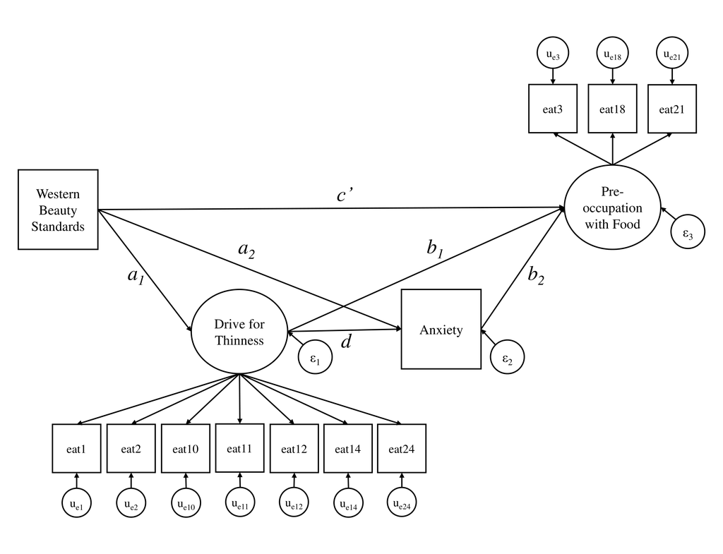

## 6.2

**Write out the structural equations necessary to evaluate the mediation hypothesis described above.**

$$\begin{align}
\eta_{pre} &= b_1 \eta_{drive} + b_2 X_{anx} + c' X_{wsb} + \varepsilon_3\\
X_{anx} &= a_2 X_{wsb} + d \eta_{drive} + \varepsilon_2\\
\eta_{drive} &= a_1 X_{wsb} + \varepsilon_1
\end{align}$$

## 6.3

**Define the model syntax for the CFA.**

The data only contain multi-item scales for *Drive for Thinness* and *Preoccupation with Food*, so we only need a two-dimensional CFA evaluating the measurement structure of these two factors.

- Indicated the *Drive for Thinness* factor from the seven relevant scale items.
  - `eat1`, `eat2`, `eat10`, `eat11`, `eat12`, `eat14`, `eat24`
- Indicated the *Preoccupation with Food* factor from the remaining three scale items.
  - `eat3`, `eat18`, `eat21`

```r
cfaMod4 <- '
drive =~ eat1 + eat2  + eat10 + eat11 + eat12 + eat14 + eat24
pre   =~ eat3 + eat18 + eat21
'
```

## 6.4

**Estimate the CFA model on the EA data.**

- Correlate the latent factors.
- Set the scale by standardizing the latent factors.
- Do not include any mean structure.

```r
cfaFit4 <- cfa(cfaMod4, data = ea, std.lv = TRUE)
```

## 6.5

**Summarize the fitted CFA and check the model fit.**

- Do the parameter estimates look sensible?
- Does the model fit the data well enough?

```r
summary(cfaFit4)
```

```
lavaan 0.6-21 ended normally after 22 iterations

  Estimator                                         ML
  Optimization method                           NLMINB
  Number of model parameters                        21

  Number of observations                           400

Model Test User Model:

  Test statistic                                68.184
  Degrees of freedom                                34
  P-value (Chi-square)                           0.000

Parameter Estimates:

  Standard errors                             Standard
  Information                                 Expected
  Information saturated (h1) model          Structured

Latent Variables:
                   Estimate  Std.Err  z-value  P(>|z|)
  drive =~
    eat1              0.733    0.049   14.997    0.000
    eat2              0.654    0.045   14.515    0.000
    eat10             0.800    0.042   19.119    0.000
    eat11             0.765    0.040   19.261    0.000
    eat12             0.648    0.047   13.793    0.000
    eat14             0.901    0.041   21.827    0.000
    eat24             0.614    0.047   13.107    0.000
  pre =~
    eat3              0.778    0.046   17.077    0.000
    eat18             0.758    0.047   16.100    0.000
    eat21             0.867    0.044   19.744    0.000

Covariances:
                   Estimate  Std.Err  z-value  P(>|z|)
  drive ~~
    pre               0.617    0.038   16.143    0.000

Variances:
                   Estimate  Std.Err  z-value  P(>|z|)
   .eat1              0.620    0.048   12.989    0.000
   .eat2              0.542    0.041   13.090    0.000
   .eat10             0.337    0.029   11.569    0.000
   .eat11             0.299    0.026   11.492    0.000
   .eat12             0.609    0.046   13.227    0.000
   .eat14             0.234    0.025    9.459    0.000
   .eat24             0.625    0.047   13.342    0.000
   .eat3              0.406    0.040   10.252    0.000
   .eat18             0.476    0.043   11.090    0.000
   .eat21             0.256    0.037    6.925    0.000
    drive             1.000
    pre               1.000
```

```r
fitMeasures(cfaFit4)
```

```
                 npar                  fmin                 chisq
               21.000                 0.085                68.184
                   df                pvalue        baseline.chisq
               34.000                 0.000              2051.279
          baseline.df       baseline.pvalue                   cfi
               45.000                 0.000                 0.983
                  tli                  nnfi                   rfi
                0.977                 0.977                 0.956
                  nfi                  pnfi                   ifi
                0.967                 0.730                 0.983
                  rni                  logl     unrestricted.logl
                0.983             -4706.491             -4672.399
                  aic                   bic                ntotal
             9454.981              9538.802               400.000
                 bic2                 rmsea        rmsea.ci.lower
             9472.168                 0.050                 0.033
       rmsea.ci.upper        rmsea.ci.level          rmsea.pvalue
                0.067                 0.900                 0.470
       rmsea.close.h0 rmsea.notclose.pvalue     rmsea.notclose.h0
                0.050                 0.002                 0.080
                  rmr            rmr_nomean                  srmr
                0.036                 0.036                 0.036
         srmr_bentler   srmr_bentler_nomean                  crmr
                0.036                 0.036                 0.040
          crmr_nomean            srmr_mplus     srmr_mplus_nomean
                0.040                 0.036                 0.036
                cn_05                 cn_01                   gfi
              286.124               329.879                 0.966
                 agfi                  pgfi                   mfi
                0.946                 0.597                 0.958
                 ecvi
                0.275
```

This model looks good. All measurement model parameters seem reasonable, and the model fits the data well.

## 6.6

**Define the model syntax for the structural model.**

- Specify all paths needed to test the multiple mediation hypothesis described above.
- Include defined parameters to quantify all specific indirect effects and the total indirect effect.

```r
## Define only the new structural parts:
semMod4 <- '
pre   ~ b1 * drive + b2 * anx + cp * wsb
anx   ~ d * drive  + a2 * wsb
drive ~ a1 * wsb

ab1 := a1 * b1
ab2 := a2 * b2
adb := a1 * d * b2
ie  := ab1 + ab2 + adb
'

## Add on the measurement part:
semMod4 <- paste(cfaMod4, semMod4, sep = '\n')
```

## 6.7

**Estimate the structural model.**

- Use B = 2000 bootstrap resamples to quantify the sampling variability.

```r
semFit4 <- sem(semMod4, data = ea, std.lv = TRUE, se = "boot", bootstrap = nSams)
summary(semFit4)
```

```
lavaan 0.6-21 ended normally after 30 iterations

  Estimator                                         ML
  Optimization method                           NLMINB
  Number of model parameters                        27

  Number of observations                           400

Model Test User Model:

  Test statistic                               139.466
  Degrees of freedom                                50
  P-value (Chi-square)                           0.000

Parameter Estimates:

  Standard errors                            Bootstrap
  Number of requested bootstrap draws             2000
  Number of successful bootstrap draws            2000

Latent Variables:
                   Estimate  Std.Err  z-value  P(>|z|)
  drive =~
    eat1              0.685    0.042   16.259    0.000
    eat2              0.609    0.045   13.420    0.000
    eat10             0.731    0.048   15.151    0.000
    eat11             0.707    0.043   16.322    0.000
    eat12             0.605    0.046   13.088    0.000
    eat14             0.825    0.044   18.676    0.000
    eat24             0.575    0.044   13.075    0.000
  pre =~
    eat3              0.592    0.044   13.577    0.000
    eat18             0.579    0.045   12.910    0.000
    eat21             0.648    0.045   14.524    0.000

Regressions:
                   Estimate  Std.Err  z-value  P(>|z|)
  pre ~
    drive     (b1)    0.556    0.090    6.198    0.000
    anx       (b2)    0.106    0.022    4.753    0.000
```

[output cut: 14 more lines]

```
   .eat14             0.248    0.027    9.017    0.000
   .eat24             0.614    0.048   12.690    0.000
   .eat3              0.398    0.040    9.989    0.000
   .eat18             0.463    0.046   10.153    0.000
   .eat21             0.274    0.042    6.576    0.000
   .anx               6.524    0.422   15.478    0.000
   .drive             1.000
   .pre               1.000

Defined Parameters:
                   Estimate  Std.Err  z-value  P(>|z|)
    ab1               0.122    0.025    4.843    0.000
    ab2              -0.005    0.008   -0.633    0.527
    adb               0.033    0.009    3.743    0.000
    ie                0.150    0.028    5.260    0.000
```

## 6.8

**Interpret the results.**

1. Is the two-step specific indirect effect through *Drive for Thinness* significant according to the 95% BC CI?
2. Is the two-step specific indirect effect through *Anxiety* significant according to the 95% BC CI?
3. Is the full, three-step specific indirect effect through *Drive for Thinness* and *Anxiety* significant according to the 95% BC CI?
4. Is the total indirect effect significant according to the 95% BC CI?
5. Briefly interpret the indirect effects.

```r
parameterEstimates(semFit4, boot.ci.type = "bca.simple") |>
  select(-(1:3)) |>
  tail(4)
```

|  | label | est | se | z | pvalue | ci.lower | ci.upper |
| --- | --- | --- | --- | --- | --- | --- | --- |
| 31 | ab1 | 0.121689709 | 0.025124719 | 4.8434256 | 1.276195e-06 | 0.07729490 | 0.1763463 |
| 32 | ab2 | -0.005019943 | 0.007926445 | -0.6333158 | 5.265274e-01 | -0.02109515 | 0.0101739 |
| 33 | adb | 0.033207107 | 0.008870702 | 3.7434587 | 1.815045e-04 | 0.01820165 | 0.0533389 |
| 34 | ie | 0.149876873 | 0.028491533 | 5.2604005 | 1.437419e-07 | 0.09610328 | 0.2078320 |

1. Yes, the two-step specific indirect effect through *Drive for Thinness* is statistically significant $(ab = 0.122,$ $95\%~\mathit{CI}_{BC} = [0.077; 0.176]).$
2. No, the two-step specific indirect effect through *anxiety* is not statistically significant $ab = -0.005,$ $95\%~\mathit{CI}_{BC} = [-0.021; 0.01]).$
3. Yes, the full, three-step specific indirect effect is statistically significant $(adb = 0.033,$ $95\%~\mathit{CI}_{BC} = [0.018; 0.053]).$
4. Yes, the total indirect effect is statistically significant $(\mathit{IE} = 0.15,$ $95\%~\mathit{CI}_{BC} = [0.096; 0.208]).$
5. The hypothesized causal chain linking Western beauty standards to preoccupation with food through drive for thinness and anxiety was supported by a statistically significant specific indirect effect. Western beauty standards had a significant, positive effect on preoccupation with food, and this effect was transmitted indirectly by first increasing the drive for thinness which subsequently increased anxiety to, finally, increase preoccupation with food.

   A subprocess by which the effect of Western beauty standards on preoccupation with food is transmitted indirectly through drive for thinness was also supported by a statistically significant, positive indirect effect. The analogous subprocess transmitted through anxiety levels was associated with a nonsignificant indirect effect and, hence, was not supported by these results.

End of Lab 4